# Group 13 - Project Part 2

#### İsmet Onur Abdioğlu 2016402186

#### Ertuğrul Arda 2015402147

#### Ali Burak Kaya 2015402165

#### Alper Vural 2016402075

#### Yavuzhan Yavuz 2015402102

#### In the second part of the project, we are asked to perform quality control tasks on the images and perform regression in order to deal with the problem of autocorrelation. In the first question, we have taken a greyscale image and tried to determine the outlier points that can also be considered as the defects on the picture or the surface. Then, we have perform a linear regression on the patches of the image in order to reduce the problem of autocorrelation between the pixel values.

# Question 1

#### In the first part, We have taken our image and converted it to a greyscale image using image editor.

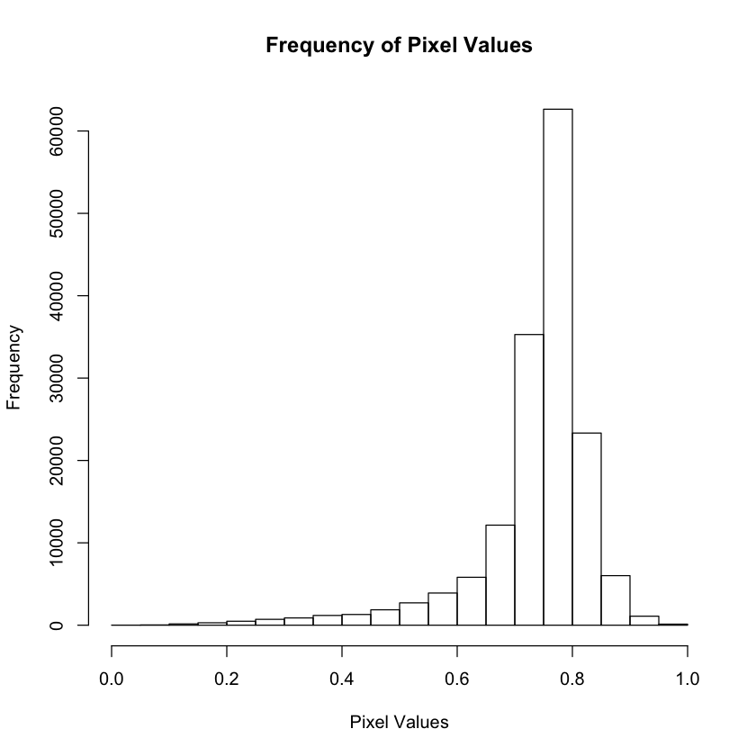

```r
library(jpeg)
surface <- readJPEG("group_13.jpeg")
grey_surface<-surface[,,1]
par(mfrow=c(1,1))
hist(grey_surface,main="Frequency of Pixel Values",xlab="Pixel Values",ylab="Frequency")
```

#### First, we observed the frequency of pixel values to see the distribution.

#### For row:

```r
row_based <- grey_surface
count_out_row <- 0
N <- nrow(grey_surface)
for(i in 1:N){
  Row<-grey_surface[i,]
  UpperR<-quantile(Row, 0.999)
  LowerR<-quantile(Row, 0.001)
  for(j in 1:N){
    if(Row[j]<LowerR || Row[j]>UpperR){
      Row[j]<-0
      count_out_row <- count_out_row + 1
    }
  }
  row_based[i,]<-Row
}
```

#### For each row we have calculated UpperR and LowerR which represent the 0.999 quantile and 0.001 quantile Respectively. The pixels that lays down above and below those limits are concluded to be out of control and their pixel values are set to 0.

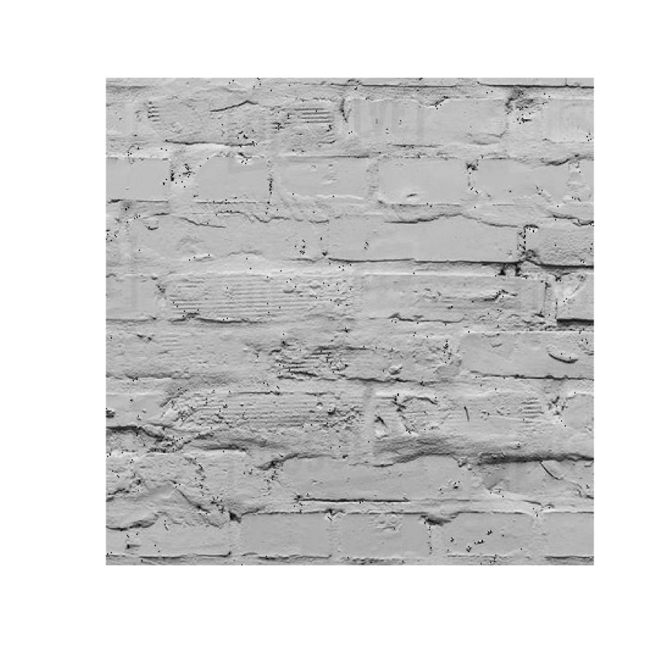

```r
surface_ras_row <- as.raster(row_based)
par(mfrow=c(1,1))
plot(surface_ras_row)
```

#### For column:

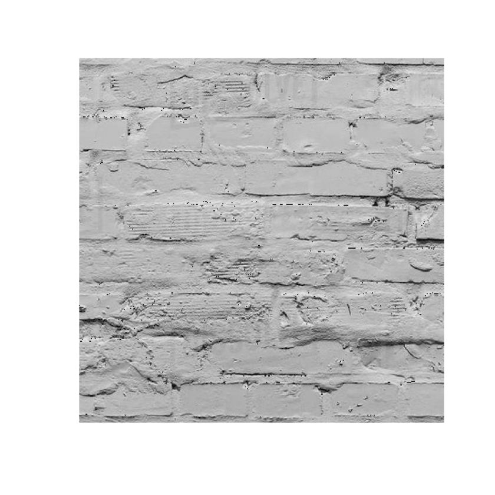

```r
col_based <- grey_surface
count_out_col <- 0
for(i in 1:N){
  Col<-grey_surface[,i]
  UpperC<-quantile(Col, 0.999)
  LowerC<-quantile(Col, 0.001)
  for(j in 1:N){
    if(Col[j]<LowerC || Col[j]>UpperC){
      Col[j]<-0
      count_out_col <- count_out_col + 1
    }
  }
  col_based[,i]<-Col
}

surface_ras_col <- as.raster(col_based)
par(mfrow=c(1,1))
plot(surface_ras_col)
```

#### For each column we have calculated UpperR and LowerR which represent the 0.999 quantile and 0.001 quantile Respectively. The pixels that lays down above and below those limits are concluded to be out of control and their pixel values are set to 0.

```r
count_out_col - count_out_row
```

5

#### After repeating this process for columns and rows, it is observed that there are 5 more out of control pixels in column based investigation which is very normal. Because, the nature of our image's pattern is horizontal. There are more similar pixels in a row based investigation than column based investigation.

# Question 2

#### In the second question, we have taken 350 * 350 many patches that has height and weight of 51 pixels from the original image. Then we have constructed a linear model that uses the pixel values around the center as predictors.

```r
DATA <- matrix(0,nrow=350*350,ncol=2601)
a<-0
for(i in 1:350){
  for(j in 1:350){
    a<-a+1
    dt <- grey_surface[i:(i+50),j:(j+50)]
    pred <- as.vector(t(dt))
    x1 <- pred[1:1300]
    x2 <- pred[1302:2601]
    y <- pred[1301]
    p <- append(x1,x2)
    row <- append(p,y)
    DATA[a,]<- row
  }

}
w<- as.data.frame(DATA)
```

```r
reg <- lm(V2601~.,data = w)
```

```r
summary(reg)
```

```
Call:
lm(formula = V2601 ~ ., data = w)

Residuals:
     Min       1Q   Median       3Q      Max
-0.53968 -0.01291  0.00029  0.01353  0.42652

Coefficients:
              Estimate Std. Error t value Pr(>|t|)
(Intercept) -1.679e-04  2.647e-03  -0.063 0.949411
V1          -3.687e-04  2.091e-03  -0.176 0.860061
V2          -6.915e-04  2.758e-03  -0.251 0.802063
V3           4.577e-04  2.810e-03   0.163 0.870606
V4          -4.706e-04  2.842e-03  -0.166 0.868450
V5           2.009e-03  2.845e-03   0.706 0.480191
V6          -2.054e-03  2.847e-03  -0.721 0.470668
V7           4.346e-03  2.847e-03   1.526 0.126894
V8          -6.488e-03  2.842e-03  -2.283 0.022460 *
V9           5.980e-03  2.838e-03   2.107 0.035089 *
V10         -4.157e-03  2.838e-03  -1.465 0.142990
V11          3.721e-03  2.835e-03   1.313 0.189321
V12         -3.209e-03  2.830e-03  -1.134 0.256853
V13          1.215e-03  2.829e-03   0.429 0.667705
V14          3.656e-04  2.828e-03   0.129 0.897119
V15         -4.314e-03  2.824e-03  -1.528 0.126630
V16          5.710e-03  2.823e-03   2.023 0.043125 *
V17         -3.892e-03  2.823e-03  -1.379 0.167911
V18          2.232e-03  2.822e-03   0.791 0.428946
V19          2.759e-04  2.822e-03   0.098 0.922107
V20         -1.470e-03  2.819e-03  -0.521 0.602125
V21          2.164e-04  2.812e-03   0.077 0.938667
V22          6.716e-05  2.811e-03   0.024 0.980940
V23         -3.501e-03  2.813e-03  -1.245 0.213291
V24          5.969e-03  2.814e-03   2.121 0.033933 *
V25         -5.474e-03  2.815e-03  -1.945 0.051820 .
V26          8.102e-03  2.813e-03   2.880 0.003980 **
V27         -8.865e-03  2.813e-03  -3.152 0.001624 **
V28          6.230e-03  2.813e-03   2.215 0.026767 *
V29         -7.580e-03  2.812e-03  -2.696 0.007024 **
V30          7.421e-03  2.812e-03   2.639 0.008306 **
```

[output cut: 2561 more lines]

```
V2592        3.530e-03  2.863e-03   1.233 0.217547
V2593       -4.097e-03  2.863e-03  -1.431 0.152427
V2594        2.993e-03  2.863e-03   1.046 0.295766
V2595       -5.162e-04  2.862e-03  -0.180 0.856887
V2596       -1.169e-04  2.861e-03  -0.041 0.967409
V2597        2.224e-04  2.858e-03   0.078 0.937984
V2598        1.793e-04  2.824e-03   0.063 0.949370
V2599       -2.011e-03  2.767e-03  -0.727 0.467351
V2600        1.770e-03  2.084e-03   0.849 0.395748
---
Signif. codes:  0 ‘***’ 0.001 ‘**’ 0.01 ‘*’ 0.05 ‘.’ 0.1 ‘ ’ 1

Residual standard error: 0.03894 on 119899 degrees of freedom
Multiple R-squared:  0.8657,	Adjusted R-squared:  0.8628
F-statistic: 297.2 on 2600 and 119899 DF,  p-value: < 2.2e-16
```

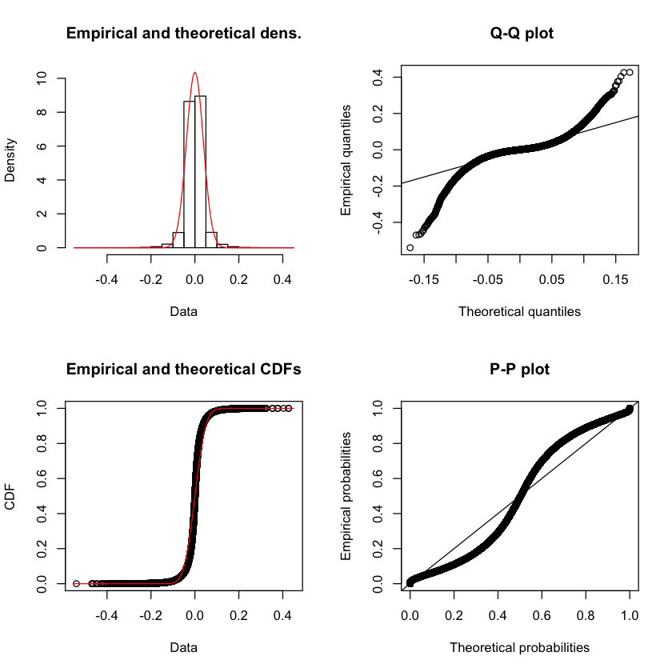

```r
library("fitdistrplus")
fitness <- fitdist(reg$residual,distr="norm")
plot(fitness)
```

#### With respect to the normality assumption, our image is adjusted by setting outlier pixels (alpha = 0.002 - two-tailed) to black color.

```r
Residuals<-reg$residual
lower_quantile<-quantile(Residuals, 0.001)
upper_quantile<-quantile(Residuals, 0.999)
grey_surface_adjusted<-grey_surface

for(i in 1:350*350){
  if((Residuals[i]<lower_quantile)|(Residuals[i]>upper_quantile)){

      if((i%%350) == 0){
      grey_surface_adjusted[(25+ceiling(i/350)),(375)]<-0

     }

      else{
      grey_surface_adjusted[(25+ceiling(i/350)),(25+(i%%350))]<-0
     }
  }
}
```

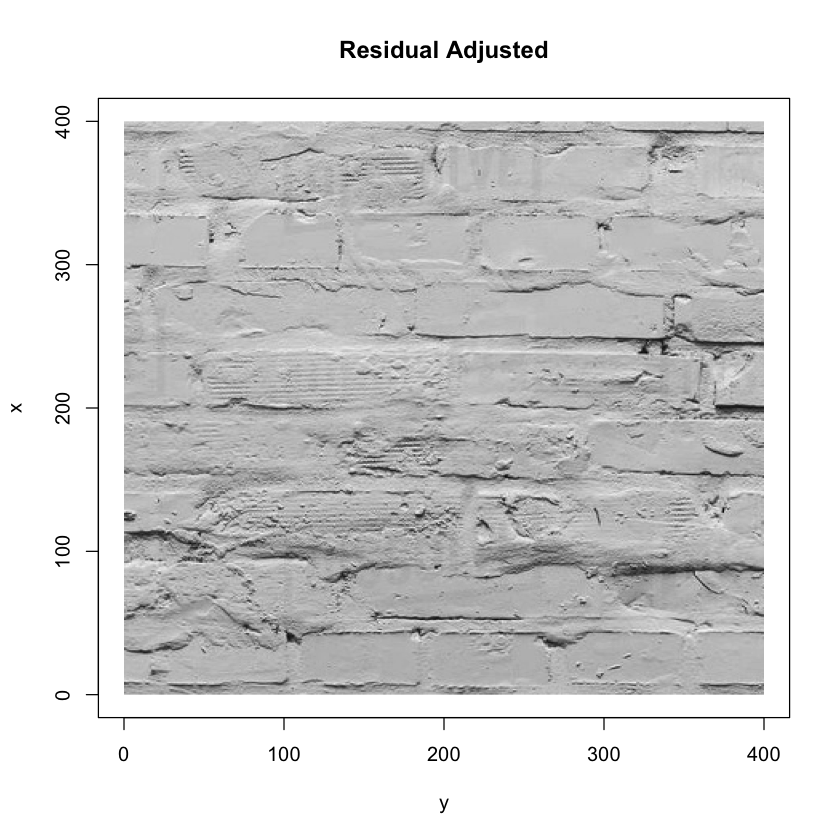

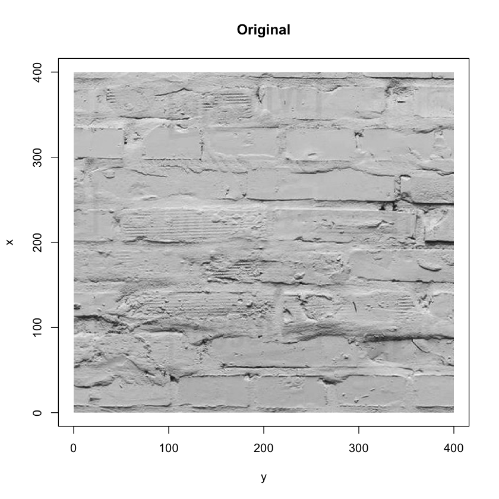

```r
plot(NA,main="Residual Adjusted",xlab= "y",ylab = "x",xlim=c(0,nrow(grey_surface_adjusted)),ylim=c(0,ncol(grey_surface_adjusted)))
rasterImage(grey_surface_adjusted,0,0,nrow(grey_surface_adjusted),ncol(grey_surface_adjusted))


plot(NA,main="Original",xlab= "y",ylab = "x",xlim=c(0,nrow(grey_surface)),ylim=c(0,ncol(grey_surface)))
rasterImage(grey_surface,0,0,nrow(grey_surface),ncol(grey_surface))
```

## In order to deal with the autocorrelation problem first we need to find autocorrelated variables. One way to do that is using variance inflation factor. There is a function in R named “vif”. This function show whether there is an autocorrelation or not. Then we can make backward elimination or forward selection to eliminate autocorrelation.m